# S4_Informe

UTEC - Universidad de Ingeniería y Tecnología

### **Estadística y Probabilidades**

#### **Correlación entre el precio del oro, plata y cobre con el precio de las acciones de empresas mineras del Perú**

**Introducción**  
La plata y el cobre son minerales que tienen valor por el uso y características que tiene, aplicándose en varias cosas útiles y necesarias para los seres humanos, como equipos electrodomésticos, equipos electrónicos e incluso joyas. Su alza de precio depende únicamente del incremento de demanda que tengan estos materiales, a diferencia del oro.

El patrón oro es un sistema monetario respaldado por oro. En otras palabras, el valor de cada unidad monetaria está determinado por una cierta cantidad de oro. Con este sistema, el emisor de la moneda se asegura que los billetes y monedas emitidos estén respaldados en oro. La moneda de referencia para el precio del oro es el dólar estadounidense. Así, cuando el valor del dólar cae, la capacidad de comprar oro aumenta para quienes pagan en otra moneda. Y viceversa, cuando el dólar está fuerte, el precio del oro es cada vez menos volátil.

Respecto a las empresas mineras, sus operaciones se centran en la extracción selectiva de minerales de la corteza terrestre. Dado que la tierra está concentrada con grandes yacimientos de minerales, muchas empresas mineras se han beneficiado y aportado a la economía de cada país. Cuando se trata de la valoración de la empresa, los precios de las acciones cambian diariamente y precisamente debido a las fuerzas del mercado, es decir, los precios de las acciones cambian según las fuerzas de este y, la oferta y la demanda. El precio de los materiales (oro, plata y cobre) influye directamente en el precio de la acción de empresa y por ende a la valorización total de la empresa.

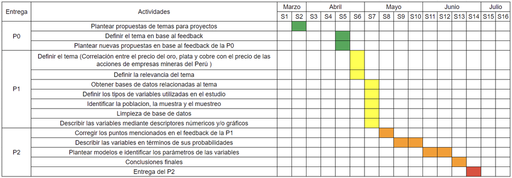

**DATOS**

- *Recolección de datos*: En el estudio realizado se utilizaran las bases de datos de las empresas mineras, la del oro, plata y cobre. La página web que proporcionó esta información es Investing, una plataforma financiera que ofrece cotizaciones de mercado, información sobre acciones, materias primas, etc.
- *Población Objetivo*: Empresas mineras del Perú
- *Tipo de Muestreo*: El muestreo es estratificado debido a que se utilizara datos según la investigación planteada
- *Tamaño de la muestra*: 5 años
- *Unidades Muestrales*: 1233 unidades muestrales

**Variables**:

- Nombre
- Fecha
- Precio de Apertura
- Precio de Cierre
- Variacion

**Tabla - Tipos de Variables**

| Variables | Tipo |
| --- | --- |
| Nombre | Categórica → Nominal |
| Fecha | Numérica → Continua |
| Precio de Apertura | Numérica → Continua |
| Precio de Cierre | Numérica → Continua |
| Variacion | Numérica→ Continua |

**Limpieza de Datos**

```r
library(readr)
library(stringr)
library(quantmod)
library(PerformanceAnalytics)
```

```r
library(dygraphs)
library(dplyr)
library(corrplot)
```

Cargamos las respuestas en un data frame inicial llamado DF:

```r
ORO = read_csv("Au.csv", show_col_types = FALSE);
PLATA = read_csv("PLATA.csv", show_col_types = FALSE);
COBRE = read_csv("COBRE.csv", show_col_types = FALSE);
BVN1 = read_csv("BVN.csv", show_col_types = FALSE);
GOLD1 = read_csv("GOLD.csv", show_col_types = FALSE);
GFI1 = read_csv("GFI.csv", show_col_types = FALSE);
```

Observamos los nombres de los encabezados:

```r
names(ORO)
```

```
## [1] "Fecha"    "Último"   "Apertura" "Máximo"   "Mínimo"   "Vol."     "% var."
```

Renombrar variables para mejorar nuestro estudio, eliminamos las variables que no utilizaremos y acomodaremos algunas variables para que luego se puedan usar:

```r
ORO = ORO[ ,c(1, 2, 3,7)]
names(ORO) <- c("Fecha",  "Cierre", "Apertura","Variacion %")
for(i in 1:nrow(ORO)){
  ORO$`Variacion %`[i] = str_sub(ORO$`Variacion %`[i],1,nchar(ORO$`Variacion %`[i])-1)
  x = ORO$`Variacion %`[i]
  a = gsub(",","\\.",x)
  a = gsub("\\,","",x)
  ORO$`Variacion %`[i] = as.numeric(a)/100
  ORO$Cierre[i] = as.numeric(ORO$Cierre[i])*1000
  ORO$Apertura[i]= as.numeric(ORO$Apertura[i])*1000
}


PLATA <- PLATA[ ,c(1, 2, 3, 7)]
names(PLATA) <- c("Fecha",  "Cierre", "Apertura", "Variacion %")
for(i in 1:nrow(PLATA)){
  PLATA$`Variacion %`[i] = str_sub(PLATA$`Variacion %`[i],1,nchar(PLATA$`Variacion %`[i])-1)
  x = PLATA$`Variacion %`[i]
  a = gsub(",","\\.",x)
  a = gsub("\\,","",x)
  PLATA$`Variacion %`[i] = as.numeric(a)/100
    PLATA$Cierre[i] = as.numeric(PLATA$Cierre[i])/1000
    PLATA$Apertura[i]= as.numeric(PLATA$Apertura[i])/1000
}

COBRE <- COBRE[ ,c(1, 2, 3,7)]
names(COBRE) <- c("Fecha",  "Cierre", "Apertura","Variacion %")
for(i in 1:nrow(COBRE)){
  COBRE$`Variacion %`[i] = str_sub(COBRE$`Variacion %`[i],1,nchar(COBRE$`Variacion %`[i])-1)
  x = COBRE$`Variacion %`[i]
  a = gsub(",","\\.",x)
  a = gsub("\\,","",x)
  COBRE$`Variacion %`[i] = as.numeric(a)/100
    COBRE$Cierre[i] = as.numeric(COBRE$Cierre[i])/10000
    COBRE$Apertura[i]= as.numeric(COBRE$Apertura[i])/10000
}


GOLD1 <- GOLD1[ ,c(1, 2, 3, 7)]
names(GOLD1) <- c("Fecha",  "Cierre", "Apertura","Variacion %")
  for(i in 1:nrow(GOLD1)){
    GOLD1$`Variacion %`[i] = str_sub(GOLD1$`Variacion %`[i],1,nchar(GOLD1$`Variacion %`[i])-1)
    x = GOLD1$`Variacion %`[i]
    a = gsub(",","\\.",x)
    a = gsub("\\,","",x)
    GOLD1$`Variacion %`[i] = as.numeric(a)/1000
    GOLD1$Cierre[i] = as.numeric(GOLD1$Cierre[i])/100
    GOLD1$Apertura[i]= as.numeric(GOLD1$Apertura[i])/100
  }

BVN1 <- BVN1[ ,c(1, 2, 3, 7)]
names(BVN1) <- c("Fecha",  "Cierre", "Apertura","Variacion %")
  for(i in 1:nrow(BVN1)){
    BVN1$`Variacion %`[i] = str_sub(BVN1$`Variacion %`[i],1,nchar(BVN1$`Variacion %`[i])-1)
    x = BVN1$`Variacion %`[i]
    a = gsub(",","\\.",x)
    a = gsub("\\,","",x)
    BVN1$`Variacion %`[i] = as.numeric(a)/1000
    BVN1$Cierre[i] = as.numeric(BVN1$Cierre[i])/1000
    BVN1$Apertura[i]= as.numeric(BVN1$Apertura[i])/1000
  }

GFI1 <- GFI1[ ,c(1, 2, 3, 7)]
names(GFI1) <- c("Fecha",  "Cierre", "Apertura","Variacion %")
  for(i in 1:nrow(GFI1)){
    GFI1$`Variacion %`[i] = str_sub(GFI1$`Variacion %`[i],1,nchar(GFI1$`Variacion %`[i])-1)
    x = GFI1$`Variacion %`[i]
    a = gsub(",","\\.",x)
    a = gsub("\\,","",x)
    GFI1$`Variacion %`[i] = as.numeric(a)/100
    GFI1$Cierre[i] = as.numeric(GFI1$Cierre[i])/1000
    GFI1$Apertura[i]= as.numeric(GFI1$Apertura[i])/1000

  }
```

Verificamos si hay datos faltantes

```r
sum(is.na(ORO))
```

```
## [1] 0
```

```r
sum(is.na(PLATA))
```

```
## [1] 0
```

```r
sum(is.na(COBRE))
```

```
## [1] 0
```

```r
sum(is.na(GOLD1))
```

```
## [1] 0
```

```r
sum(is.na(GFI1))
```

```
## [1] 0
```

```r
sum(is.na(BVN1))
```

```
## [1] 0
```

Igualamos el numero de observaciones y fechas:

```r
for(i in 1:nrow(GOLD1)){
  if(ORO$Fecha[i] != GOLD1$Fecha[i]){
      ORO = ORO[-c(i), ]
  }
}

for(i in 1:nrow(GOLD1)){
  if(PLATA$Fecha[i] != GOLD1$Fecha[i]){
      PLATA = PLATA[-c(i), ]
  }
}

for(i in 1:nrow(GOLD1)){
  if(COBRE$Fecha[i] != GOLD1$Fecha[i]){
      COBRE = COBRE[-c(i), ]
  }
}


Au = c()
for(i in 1:nrow(GOLD1)){
  if(ORO$Fecha[i] != GOLD1$Fecha[i]){
    Au = c(i ,Au)
  }
}

Ag = c()
for(i in 1:nrow(GOLD1)){
  if(PLATA$Fecha[i] != GOLD1$Fecha[i]){
    Ag = c(i ,Ag)
  }
}

Cu = c()
for(i in 1:nrow(GOLD1)){
  if(COBRE$Fecha[i] != GOLD1$Fecha[i]){
    Cu = c(i ,Cu)
  }
}

Limpio = c(Au, Ag, Cu)


ORO = ORO[-c(Limpio), ]
PLATA = PLATA[-c(Limpio), ]
COBRE = COBRE[-c(Limpio), ]
GFI1 = GFI1[-c(Limpio), ]
BVN1 = BVN1[-c(Limpio), ]
GOLD1 = GOLD1[-c(Limpio), ]
```

Verificamos que tengan el mismo numero de columnas y filas:

```r
ncol(ORO)
```

```
## [1] 4
```

```r
ncol(PLATA)
```

```
## [1] 4
```

```r
ncol(COBRE)
```

```
## [1] 4
```

```r
ncol(GOLD1)
```

```
## [1] 4
```

```r
ncol(GFI1)
```

```
## [1] 4
```

```r
ncol(BVN1)
```

```
## [1] 4
```

```r
nrow(ORO)
```

```
## [1] 1233
```

```r
nrow(PLATA)
```

```
## [1] 1233
```

```r
nrow(COBRE)
```

```
## [1] 1233
```

```r
nrow(GOLD1)
```

```
## [1] 1233
```

```r
nrow(BVN1)
```

```
## [1] 1233
```

```r
nrow(GFI1)
```

```
## [1] 1233
```

**Descriptores**

- *Descriptores Numéricos*

Hallamos los descriptores numericos que nos ofrece summary **(media, cuartil, mediana, maximo y minimo)** en aquellas variables significativas:

```r
summary(ORO$Cierre)
```

```
##    Min. 1st Qu.  Median    Mean 3rd Qu.    Max.
##    1177    1292    1508    1556    1813    2055
```

```r
summary(as.numeric(ORO$`Variacion %`))
```

```
##     Min.  1st Qu.   Median     Mean  3rd Qu.     Max.
## -4.93000 -0.37000  0.06000  0.03004  0.50000  5.95000
```

```r
summary(PLATA$Cierre)
```

```
##    Min. 1st Qu.  Median    Mean 3rd Qu.    Max.
##   11.77   16.03   17.38   19.49   23.96   29.44
```

```r
summary(as.numeric(PLATA$`Variacion %`))
```

```
##       Min.    1st Qu.     Median       Mean    3rd Qu.       Max.
## -13.290000  -0.750000   0.010000  -0.008256   0.830000   7.510000
```

```r
summary(COBRE$Cierre)
```

```
##    Min. 1st Qu.  Median    Mean 3rd Qu.    Max.
##   2.167   2.786   3.056   3.306   3.991   4.912
```

```r
summary(as.numeric(COBRE$`Variacion %`))
```

```
##     Min.  1st Qu.   Median     Mean  3rd Qu.     Max.
## -6.62000 -0.65000  0.06000  0.07715  0.83000  5.79000
```

```r
summary(GOLD1$Cierre)
```

```
##    Min. 1st Qu.  Median    Mean 3rd Qu.    Max.
##    9.70   13.52   17.77   18.20   21.52   30.29
```

```r
summary(as.numeric(GOLD1$`Variacion %`))
```

```
##      Min.   1st Qu.    Median      Mean   3rd Qu.      Max.
## -1.034000 -0.116000  0.000000  0.003405  0.113000  1.521000
```

```r
summary(BVN1$Cierre)
```

```
##    Min. 1st Qu.  Median    Mean 3rd Qu.    Max.
##    6.00   10.06   12.77   12.33   14.83   17.74
```

```r
summary(as.numeric(BVN1$`Variacion %`))
```

```
##       Min.    1st Qu.     Median       Mean    3rd Qu.       Max.
## -2.3380000 -0.1430000  0.0000000  0.0006529  0.1440000  2.7610000
```

```r
summary(GFI1$Cierre)
```

```
##    Min. 1st Qu.  Median    Mean 3rd Qu.    Max.
##   2.290   3.910   5.730   6.943   9.590  16.710
```

```r
summary(as.numeric(GFI1$`Variacion %`))
```

```
##     Min.  1st Qu.   Median     Mean  3rd Qu.     Max.
## -23.7600  -1.7300   0.0000   0.1427   1.9800  26.7800
```

- *Descriptores Gráficos*

**Gráfica de la variación del precio de las acciones de las empresas mineras**

```r
simbolos<-c("GOLD","BVN","GFI")
getSymbols(simbolos, src = 'yahoo', from = "2017-06-01",to = "2022-06-01")
```

```
## [1] "GOLD" "BVN"  "GFI"
```

```r
precios.activos <- cbind(Ad(GOLD),Ad(BVN),Ad(GFI))
names(precios.activos) <- c("GOLD","BVN","GFI")
precios.activos %>% dygraph(width=800,height=360, , main = "GOLD - BVN - GFI") %>% dyRangeSelector
```

[interactive chart not shown]

En esta gráfica podemos observar la variación del precio de las acciones de las empresas mineras seleccionadas. En donde apreciamos que la empresa GOLD se ha mantenido con un precio mayor que las otras dos empresas y que la empresa GFI inicialmente tuvo un crecimiento lento, sin embargo a partir del año 2020 la variación del precio se incrementó logrando sobrepasar el precio de la acción de la empresa BVN.

**Gráficas de la variación del precio de los metales**

```r
simbolos<-c("GC=F")
getSymbols(simbolos, src = 'yahoo', from = "2017-06-01",to = "2022-06-01")
```

```
## [1] "GC=F"
```

```r
precios.activos <- cbind(Ad(`GC=F`))
names(precios.activos) <- c("GC=F")
precios.activos %>% dygraph(width=800,height=360, main = "ORO") %>% dyRangeSelector
```

[interactive chart not shown]

```r
simbolos<-c("SI=F")
getSymbols(simbolos, src = 'yahoo', from = "2017-06-01",to = "2022-06-01")
```

```
## [1] "SI=F"
```

```r
precios.activos <- cbind(Ad(`SI=F`))
names(precios.activos) <- c("SI=F")
precios.activos %>% dygraph(width=800,height=360, main = "PLATA") %>% dyRangeSelector
```

[interactive chart not shown]

```r
simbolos<-c("HG=F")
getSymbols(simbolos, src = 'yahoo', from = "2017-06-01",to = "2022-06-01")
```

```
## [1] "HG=F"
```

```r
precios.activos <- cbind(Ad(`HG=F`))
names(precios.activos) <- c("HG=F")
precios.activos %>% dygraph(width=800,height=360, main = "COBRE") %>% dyRangeSelector
```

[interactive chart not shown]

En estas gráficas podemos observar la variación del precio de los minerales, en donde se puede apreciar que el oro tiene mucho más valor que los otros metales. Como se dijo anteriormente, el oro tiene todo un sistema financiero respaldo que puede justificar su valor para las personas y en las economías de los países, es un metal muy precioso independientemente de su tamaño, por lo que se requiere muy poco de esta sustancia para formar una moneda valiosa. Esto es diferente a los metales utilizados en la antigüedad, como el cobre que es una moneda de cobre requiere una mayor cantidad de material para lograr un alto valor, lo que dificulta el transporte de la moneda.

**Matriz de correlación de la variación**

```r
Variacion <- PLATA%>% mutate(O = ORO$`Variacion %`, P = PLATA$`Variacion %`, C = COBRE$`Variacion %`, G = GOLD1$`Variacion %`, B = BVN1$`Variacion %`, GF = GFI1$`Variacion %`)

DF <- Variacion[ ,c(5, 6, 7, 8, 9,10)]
colnames(DF)[1:6]<-c("ORO","PLATA", "COBRE","GOLD","BVN","GFI")
DF$ORO = as.numeric(DF$ORO)
DF$PLATA = as.numeric(DF$PLATA)
DF$COBRE = as.numeric(DF$COBRE)
DF$GOLD = as.numeric(DF$GOLD)
DF$BVN = as.numeric(DF$BVN)
DF$GFI = as.numeric(DF$GFI)
Cor<-(cor(DF))
Corr<-(cor(DF))

round(Corr,2)
```

```
##        ORO PLATA COBRE GOLD  BVN  GFI
## ORO   1.00  0.78  0.19 0.65 0.39 0.56
## PLATA 0.78  1.00  0.31 0.52 0.39 0.46
## COBRE 0.19  0.31  1.00 0.18 0.26 0.15
## GOLD  0.65  0.52  0.18 1.00 0.52 0.67
## BVN   0.39  0.39  0.26 0.52 1.00 0.54
## GFI   0.56  0.46  0.15 0.67 0.54 1.00
```

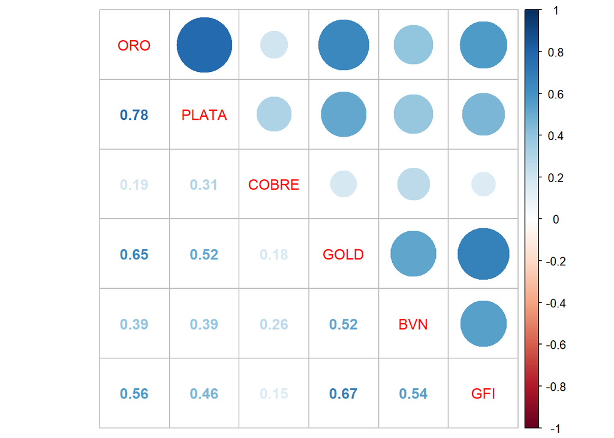

```r
corrplot.mixed(Corr)
```

**Matriz de correlación del precio de cierre**

```r
#Cierre
Cierre <- PLATA%>% mutate(O = ORO$Cierre, P = PLATA$Cierre, C = COBRE$Cierre, G = GOLD1$Cierre, B = BVN1$Cierre, GF = GFI1$Cierre)

DS <- Cierre[ ,c(5, 6, 7, 8, 9,10)]
colnames(DS)[1:6]<-c("ORO","PLATA", "COBRE","GOLD","BVN","GFI")
DS$ORO = as.numeric(DS$ORO)
DS$PLATA = as.numeric(DS$PLATA)
DS$COBRE = as.numeric(DS$COBRE)
DS$GOLD = as.numeric(DS$GOLD)
DS$BVN = as.numeric(DS$BVN)
DS$GFI = as.numeric(DS$GFI)
Cor<-(cor(DS))
Corr<-(cor(DS))

round(Corr,2)
```

```
##         ORO PLATA COBRE  GOLD   BVN   GFI
## ORO    1.00  0.88  0.60  0.90 -0.67  0.95
## PLATA  0.88  1.00  0.76  0.75 -0.54  0.87
## COBRE  0.60  0.76  1.00  0.32 -0.54  0.66
## GOLD   0.90  0.75  0.32  1.00 -0.55  0.87
## BVN   -0.67 -0.54 -0.54 -0.55  1.00 -0.60
## GFI    0.95  0.87  0.66  0.87 -0.60  1.00
```

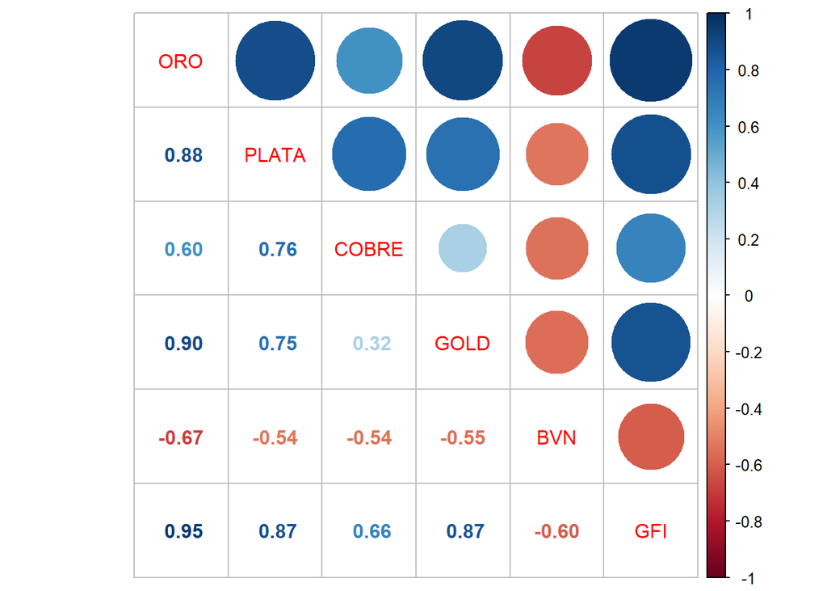

```r
corrplot.mixed(Corr)
```

**¿Cuál es el mineral que tiene menor variación?**

Para comparar la variación del precio del valor del oro, plata y cobre, utilizaremos un diagrama de caja (Boxplot).

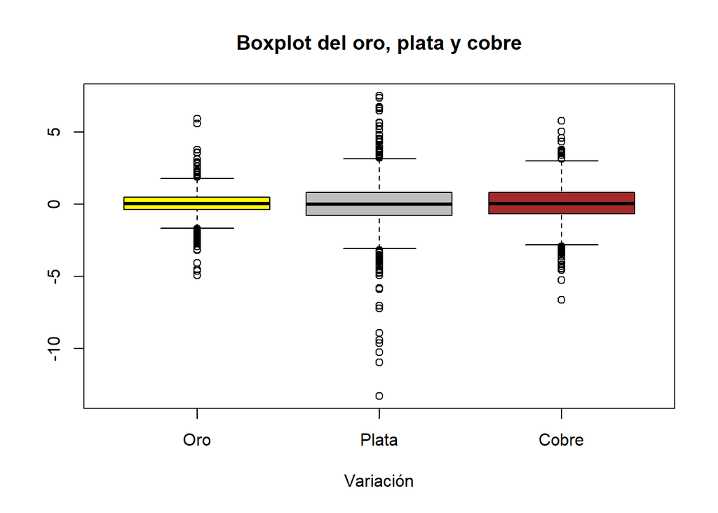

```r
boxplot(  as.numeric(ORO$`Variacion %`)
        , as.numeric(PLATA$`Variacion %`)
        , as.numeric(COBRE$`Variacion %`)
        , main = "Boxplot del oro, plata y cobre"
        , col = c( "yellow", "grey","brown")
        , xlab = "Variación"
        , names = c("Oro", "Plata", "Cobre")
        , horizontal = FALSE
        )
```

En el siguiente gráfico se puede observar la variación de los 3 minerales estudiados (oro, plata y cobre). Vemos que la mediana de los 3 se acerca a 0 y que el mineral con menor variación es el oro y el que tiene más variación es la plata, que además es el que tiene más datos atípicos de los tres. Como se dijo anteriormente, el oro se ve afectado en menor proporción que el resto de metales, Una posible explicación es que el oro en sí es un activo cotizado y se considera un refugio seguro porque tiende a mantener el valor en situaciones volátiles. Asimismo, se ve como una cobertura contra la inflación porque tiende a preservar el valor frente al aumento de precios. Por otro lado, el aumento de la demanda del resto de minerales ha provocado que su precio suba.

**¿Cuál es la empresa que tiene mayor variación?**

Para comparar la variación del precio de las acciones de las empresas mineras, utilizaremos un diagrama de caja (Boxplot) que nos pueda mostrar la información necesaria para responder la pregunta. Fue necesario utilizar esta herramienta dos veces, debidos a que la variación de una de las empresas (GFI) era mucho más grande a comparación de las otras dos.

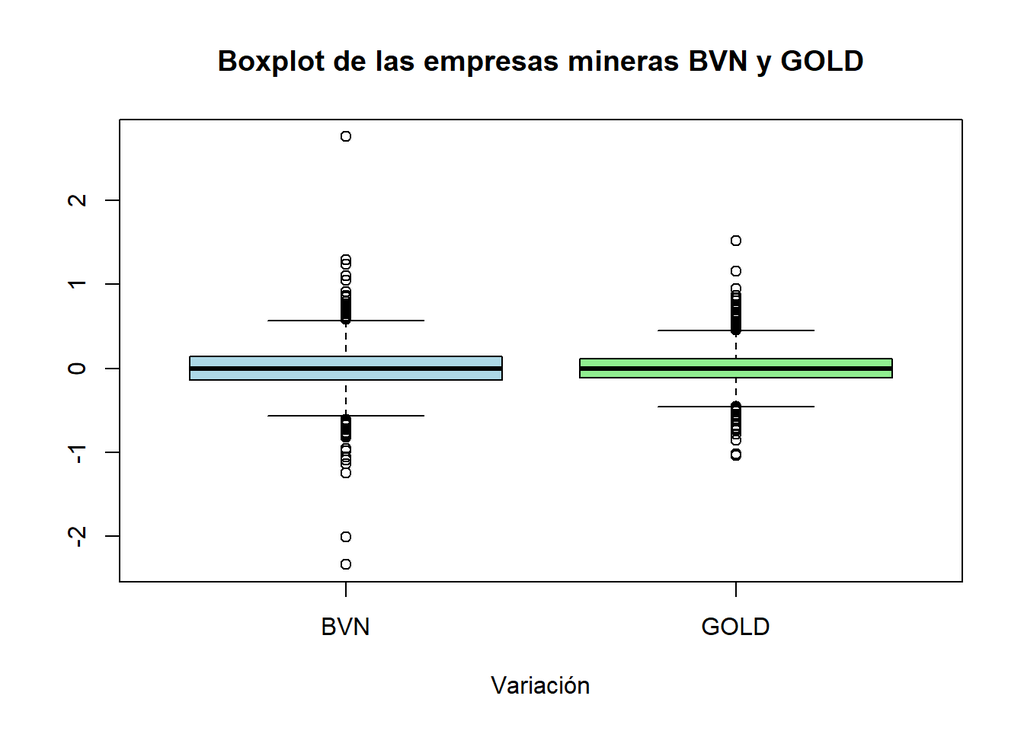

```r
boxplot(  as.numeric(BVN1$`Variacion %`)
        , as.numeric(GOLD1$`Variacion %`)
        , main = "Boxplot de las empresas mineras BVN y GOLD"
        , col = c( "light blue", "light green")
        , xlab = "Variación"
        , names = c("BVN", "GOLD")
        , horizontal = FALSE
        )
```

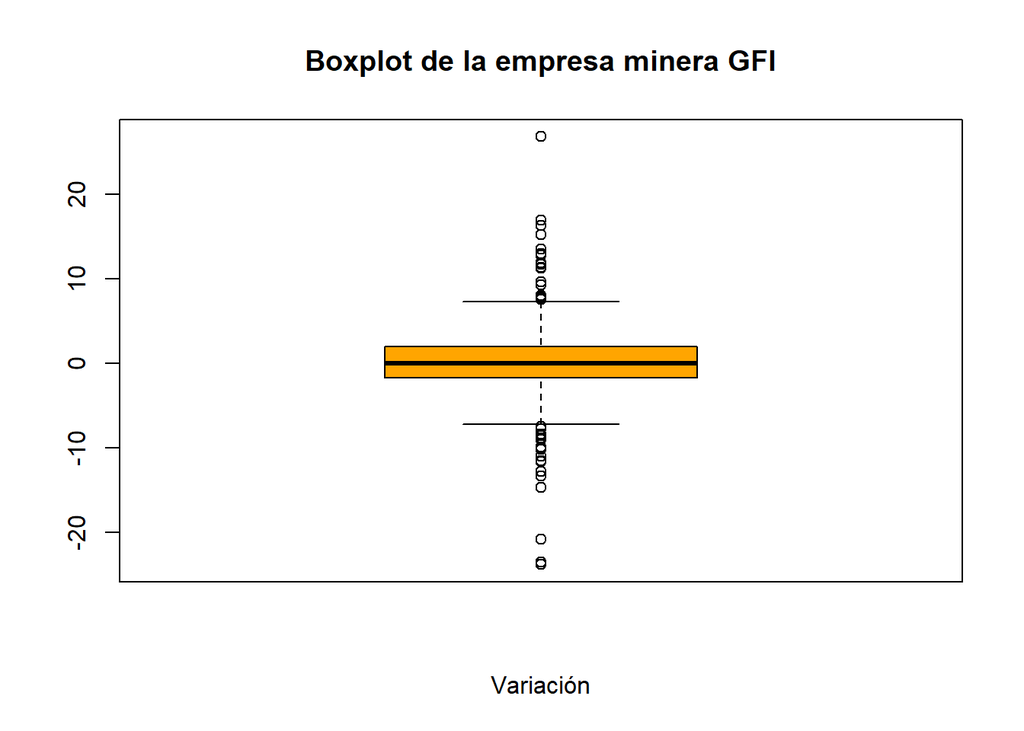

```r
boxplot(as.numeric(GFI1$`Variacion %`)
        ,main = "Boxplot de la empresa minera GFI"
        , col = c( "orange")
        , xlab = "Variación"
        , names = c("GFI")
        , horizontal = FALSE)
```

En las gráficas de las empresas (BVN, GOLD y GFI) podemos observar la variación de los precios de las acciones de estas empresas y vemos que, al igual que los materiales, la variación tiende a 0. Se puede apreciar también que la empresa BVN tiene datos atípicos más alejados a comparación de la empresa GOLD. Finalmente, también se puede apreciar que la empresa minera GFI es la que más variación estándar tiene de las tres empresas, por lo tanto tiene más variación.

Leyenda:  
Promedio = Color negro  
Mediana = Color morado

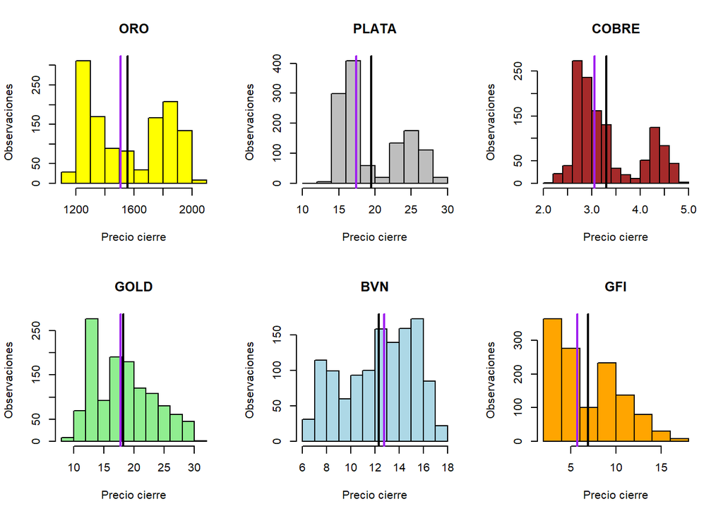

```r
op=par(mfrow=c(2,3))

hist(ORO$Cierre, breaks=10, main="ORO", col=c("yellow"),xlab="Precio cierre",ylab = "Observaciones")
abline(v = mean(as.numeric(ORO$Cierre))  , col ="black", lwd = 2)
abline(v = median(as.numeric(ORO$Cierre)), col = "purple", lwd = 2)


hist(PLATA$Cierre, breaks=10, main = "PLATA",col=c("grey"), xlab="Precio cierre",ylab = "Observaciones")
abline(v = mean(as.numeric(PLATA$Cierre))  , col ="black", lwd = 2)
abline(v = median(as.numeric(PLATA$Cierre)), col = "purple", lwd = 2)


hist(COBRE$Cierre, breaks=10, main = "COBRE",col=c("brown"), xlab="Precio cierre",ylab = "Observaciones")
abline(v = mean(as.numeric(COBRE$Cierre))  , col ="black", lwd = 2)
abline(v = median(as.numeric(COBRE$Cierre)), col = "purple", lwd = 2)


hist(GOLD1$Cierre, breaks=10, main = "GOLD",col=c("light green"), xlab="Precio cierre",ylab = "Observaciones")
abline(v = mean(as.numeric(GOLD1$Cierre))  , col ="black", lwd = 2)
abline(v = median(as.numeric(GOLD1$Cierre)), col = "purple", lwd = 2)

hist(BVN1$Cierre, breaks=10, main = "BVN",col=c("light blue"), xlab="Precio cierre",ylab = "Observaciones")
abline(v = mean(as.numeric(BVN1$Cierre))  , col ="black", lwd = 2)
abline(v = median(as.numeric(BVN1$Cierre)), col = "purple", lwd = 2)


hist(GFI1$Cierre,breaks=10, main="GFI",col=c("orange"), xlab="Precio cierre", ylab = "Observaciones")
abline(v = mean(as.numeric(GFI1$Cierre))  , col ="black", lwd = 2)
abline(v = median(as.numeric(GFI1$Cierre)), col = "purple", lwd = 2)
```

```r
par(op)
```

**Observaciones**  
Se realizó esta comparación de histograma para tener una idea más clara de cada variable, se puede observar de cómo se puede modelar cada variable como por ejemplo, los precios de cierre de GOLD,BVN y GFI. También se puede observar los precios de cierre del oro ,plata y cobre. Teniendo en cuenta que en la primera gráfica del precio de cierre del oro es una variable aleatoria y por el comportamiento que presenta podemos deducir que es una gráfica binomial. Por otro lado, vemos que el promedio es mayor a la mediana por lo tanto es una gráfica sesgada a la derecha.

La gráfica con relación del Gold esta gráfica nos presenta una variable aleatoria continua por ende nos presenta una gráfica de distribución normal, a igual de que los demás se identificó según los datos proporcionados.Por otro lado, como la mediana es igual al promedio esta es una gráfica simétrica.

La gráfica con relación de GFI a simple vista nos presenta una variable aleatoria continua por ende nos muestra una distribución binomial ya que esto sucede gracias a una correlación más directa. La gráfica de esta empresa minera al tener su promedio mayor a la mediana se encuentra sesgada a la derecha.

**Conclusiones**

- Mediante los histogramas podemos observar que las gráficas del mineral de oro, plata y cobre y las empresas mineras BVN y GFI presentan un modelo de distribución binomial. Por otro lado, la empresa minera GOLD presenta un modelo de distribución normal.
- Las gráficas de histograma del oro, plata, cobre y la empresa minera GFI presentan que el promedio es mayor a la mediana, por lo que presentan un sesgo a la derecha. En el caso de la empresa BVN al tener al lado derecho a la mediana y al izquierdo al promedio presenta un sesgo a la izquierda. Por último, la empresa GOLD al tener una diferencia mínima en cuanto a su promedio y mediana, esta gráfica presenta cierta simetría por lo que se puede concluir que los datos son simétricos.
- En el gráfico de correlación de variación podemos ver como es la relación que existe entre los minerales y las empresas mineras. Podemos concluir que en el caso del oro con las tres empresas mineras presenta un círculo azul lo que indica que existe una correlación positiva, es decir al aumentarse la variación en el precio del oro aumenta también la variación en el valor de la acción de las tres empresas mineras. Este aumento se presenta más en la empresa minera GOLD puesto que el color del cículo más oscuro que las demás empresas.
- En el gráfico de correlación del precio de cierre vemos que la empresa minera BVN presenta una correlación inversa con los tres materiales, mayormente con el oro y esto se puede deducir por lo oscuro que se encuentra el círculo rojo. Esto significa que si el precio de cierre del mineral de plata disminuye, el precio de cierre de la acción subirá y de igual manera con los demás minerales.
- En los diagramas de boxplot de las empresas mineras se puede observar como la empresa GFI es la que presenta mayor dispersión en sus datos de la variable variación y en el caso de los minerales(oro, plata y cobre) vemos que el oro es el que presenta la menor variación esto puede deberse principalmente a que el oro es un activo cotizado y se considera un refugio seguro porque tiende a mantener el valor en situaciones volátiles.

**Bibliografía**

Aguilar, J. F. (2021, September 2). Oro. Retrieved from https://economipedia.com/definiciones/oro.html  
Monex. (2022, March 29). Retrieved from https://blog.monex.com.mx/escuela-de-finanzas/por-que-suben-y-bajan-los-precios-de-las-acciones#:~:text=La%20cotizaci%C3%B3n%20de%20las%20acciones  
Pedraza, J. A. (2018, July 7). ¿Qué es y cómo funciona el patrón oro? Retrieved from https://oroinformacion.com/que-es-y-como-funciona-el-patron-oro/#:~:text=El%20patr%C3%B3n%20oro%20es%20un,emitidos%20est%C3%A1n%20respaldados%20por%20oro  
Singular Bank. (2022, April 7). ¿Por qué sube y baja el precio del oro? [web log]. Retrieved from https://blog.selfbank.es/por-que-sube-y-baja-el-precio-del-oro/#:~:text=La%20divisa%20de%20referencia%20para,bajo%20y%20es%20menos%20vol%C3%A1til